# Sydney Suburbs and Beaches: A Study

## Libraries and Data Preparation

```python
import pandas as pd
import numpy as np
import matplotlib.pyplot as plt
import geopandas
import descartes
import seaborn as sns

from sklearn.model_selection import train_test_split, cross_val_score
from sklearn.metrics import accuracy_score, confusion_matrix, classification_report
from sklearn import svm
from sklearn.feature_selection import SelectKBest, chi2, RFECV
from sklearn.ensemble import RandomForestClassifier
from sklearn.linear_model import LogisticRegression

import warnings
warnings.filterwarnings('ignore')

pd.options.display.float_format = '{:,.2f}'.format
%matplotlib inline
```

```python
# load all the datasets
Persons_AGE10P_df = pd.read_csv('data/2016 Census - Cultural Diversity/SA2_by_AGE10P_CountingPersonsPlaceofUsualResidence.csv')
Persons_WeekyTotalPersonalIncome_df = pd.read_csv('data/2016 Census - Cultural Diversity/SA2_by_INCPTotalPersonalIncome(weekly)_CountingPersonsPlaceofUsualResidence.csv')
Persons_DistancetoWork_df = pd.read_csv('data/2016 Census - Employment, Income and Education/SA2_by_DTWP1DigitLevel_CountingPersonsPlaceofUsualResidence.csv')
Persons_EducationLevel_df = pd.read_csv('data/2016 Census - Employment, Income and Education/SA2_by_HEAP1DigitLevel_CountingPersonsPlaceofUsualResidence.csv')
Dwellings_WeeklyRent_df = pd.read_csv('data/2016 Census - Selected Dwelling Characteristics/SA2_by_RNTRDRent(weekly)Ranges_CountingDwellingsPlaceofEnumeration.csv')
Dwellings_NumberofMotorVehicles_df = pd.read_csv('data/2016 Census - Selected Dwelling Characteristics/SA2_by_VEHRDNumberofMotorVehicles(ranges)_CountingDwellingsPlaceofEnumeration.csv')
Families_CountofChildren_df = pd.read_csv('data/2016 Census - Selected Family Characteristics/SA2_by_CACFCountofAllChildreninFamily_CountingFamiliesPlaceofEnumeration.csv')
Is_Beach_df = pd.read_csv('data/is_beach.csv', index_col=1)

# remove last row and last 2 columns
Persons_AGE10P_df = Persons_AGE10P_df.iloc[0:-1,0:-2]
Persons_WeekyTotalPersonalIncome_df = Persons_WeekyTotalPersonalIncome_df.iloc[0:-1,0:-2]
Persons_DistancetoWork_df = Persons_DistancetoWork_df.iloc[0:-1,0:-2]
Persons_EducationLevel_df = Persons_EducationLevel_df.iloc[0:-1,0:-2]
Dwellings_WeeklyRent_df = Dwellings_WeeklyRent_df.iloc[0:-1,0:-2]
Dwellings_NumberofMotorVehicles_df = Dwellings_NumberofMotorVehicles_df.iloc[0:-1,0:-2]
Families_CountofChildren_df = Families_CountofChildren_df.iloc[0:-1,0:-2]
Is_Beach_df = Is_Beach_df.drop(['Unnamed: 0'], axis=1)

# reset index
Persons_AGE10P_df = Persons_AGE10P_df.rename(columns={'AGE10P - Age in Ten Year Groups': 'suburbs'})
Persons_AGE10P_df = Persons_AGE10P_df.set_index('suburbs')
Persons_WeekyTotalPersonalIncome_df = Persons_WeekyTotalPersonalIncome_df.rename(columns={'INCP Total Personal Income (weekly)':'suburbs'})
Persons_WeekyTotalPersonalIncome_df = Persons_WeekyTotalPersonalIncome_df.set_index('suburbs')
Persons_DistancetoWork_df = Persons_DistancetoWork_df.rename(columns={'DTWP - 1 Digit Level' : 'suburbs'})
Persons_DistancetoWork_df = Persons_DistancetoWork_df.set_index('suburbs')
Persons_EducationLevel_df = Persons_EducationLevel_df.rename(columns={'HEAP - 1 Digit Level' : 'suburbs'})
Persons_EducationLevel_df = Persons_EducationLevel_df.set_index('suburbs')
Dwellings_WeeklyRent_df = Dwellings_WeeklyRent_df.rename(columns={'RNTRD Rent (weekly) Ranges' : 'suburbs'})
Dwellings_WeeklyRent_df = Dwellings_WeeklyRent_df.set_index('suburbs')
Dwellings_NumberofMotorVehicles_df = Dwellings_NumberofMotorVehicles_df.rename(columns={'VEHRD Number of Motor Vehicles (ranges)' : 'suburbs'})
Dwellings_NumberofMotorVehicles_df = Dwellings_NumberofMotorVehicles_df.set_index('suburbs')
Families_CountofChildren_df = Families_CountofChildren_df.rename(columns={'CACF Count of All Children in Family' : 'suburbs'})
Families_CountofChildren_df = Families_CountofChildren_df.set_index('suburbs')
```

```python
# create dataframe with all available features combined
dfs = [Persons_AGE10P_df,
       Persons_WeekyTotalPersonalIncome_df,
       Persons_DistancetoWork_df,
       Persons_EducationLevel_df,
       Dwellings_WeeklyRent_df,
       Dwellings_NumberofMotorVehicles_df,
       Families_CountofChildren_df]
combined_df = dfs[0].join(dfs[1:])
combined_df.sample(5)
```

| suburbs | 0-9 years | 10-19 years | 20-29 years | 30-39 years | 40-49 years | 50-59 years | 60-69 years | 70-79 years | 80-89 years | 90-99 years | ... | One motor vehicle | Two motor vehicles | Three motor vehicles | Four or more motor vehicles | One child in family | Two children in family | Three children in family | Four children in family | Five children in family | Six or more children in family |
| --- | --- | --- | --- | --- | --- | --- | --- | --- | --- | --- | --- | --- | --- | --- | --- | --- | --- | --- | --- | --- | --- |
| Guildford - South Granville | 3605 | 2967 | 3566 | 3180 | 2315 | 2193 | 1580 | 940 | 490 | 113 | ... | 1947 | 1716 | 646 | 420 | 1236 | 980 | 724 | 439 | 127 | 78 |
| Maroubra - West | 1162 | 1096 | 2155 | 1627 | 1310 | 1060 | 799 | 593 | 323 | 74 | ... | 1638 | 1004 | 207 | 79 | 664 | 666 | 182 | 30 | 8 | 0 |
| Concord West - North Strathfield | 2807 | 1964 | 6730 | 5538 | 2712 | 2236 | 1568 | 790 | 401 | 102 | ... | 4624 | 2217 | 484 | 210 | 1842 | 1314 | 311 | 51 | 7 | 3 |
| Potts Point - Woolloomooloo | 615 | 597 | 5529 | 5525 | 3012 | 2387 | 1835 | 970 | 546 | 182 | ... | 3884 | 722 | 69 | 50 | 554 | 216 | 30 | 4 | 3 | 0 |
| Riverstone - Marsden Park | 2799 | 2187 | 2419 | 3171 | 2412 | 1816 | 1429 | 774 | 257 | 41 | ... | 1519 | 2209 | 750 | 481 | 1316 | 1289 | 439 | 125 | 41 | 14 |

5 rows × 72 columns

```python
# prepare a new dataframe where several features are combined for correlation analysis
merged_features_df = combined_df.copy()

# combine several age groups
merged_features_df['age_0-29 years'] = merged_features_df.loc[:,['0-9 years',
                                                             '10-19 years',
                                                             '20-29 years']].sum(axis=1)
merged_features_df['age_30-59 years'] = merged_features_df.loc[:,['30-39 years',
                                                              '40-49 years',
                                                              '50-59 years']].sum(axis=1)
merged_features_df['age_60 years and over'] = merged_features_df.loc[:,['60-69 years',
                                                                    '70-79 years',
                                                                    '80-89 years',
                                                                    '90-99 years',
                                                                    '100 years and over']].sum(axis=1)
merged_features_df.drop(['0-9 years', '10-19 years', '20-29 years',
                         '30-39 years', '40-49 years', '50-59 years',
                         '60-69 years', '70-79 years', '80-89 years',
                         '90-99 years', '100 years and over'],
                        axis=1,
                        inplace=True)

# combine several weekly income
merged_features_df['we_inccome_$1 - $499'] = merged_features_df.loc[:,['$1-$149 ($1-$7,799)',
                                                            '$150-$299 ($7,800-$15,599)',
                                                            '$300-$399 ($15,600-$20,799)',
                                                            '$400-$499 ($20,800-$25,999)']].sum(axis=1)
merged_features_df['we_income_#500 - $1,249'] = merged_features_df.loc[:,['$500-$649 ($26,000-$33,799)',
                                                                '$650-$799 ($33,800-$41,599)',
                                                                '$800-$999 ($41,600-$51,999)',
                                                                '$1,000-$1,249 ($52,000-$64,999)']].sum(axis=1)
merged_features_df['we_income_$1,250 - $3,000 or more'] = merged_features_df.loc[:,['$1,250-$1,499 ($65,000-$77,999)',
                                                                          '$1,500-$1,749 ($78,000-$90,999)',
                                                                          '$1,750-$1,999 ($91,000-$103,999)',
                                                                          '$2,000-$2,999 ($104,000-$155,999)',
                                                                          '$3,000 or more ($156,000 or more)']].sum(axis=1)
merged_features_df.drop(['$1-$149 ($1-$7,799)', '$150-$299 ($7,800-$15,599)', '$300-$399 ($15,600-$20,799)',
                         '$400-$499 ($20,800-$25,999)', '$500-$649 ($26,000-$33,799)', '$650-$799 ($33,800-$41,599)',
                         '$800-$999 ($41,600-$51,999)', '$1,000-$1,249 ($52,000-$64,999)','$1,250-$1,499 ($65,000-$77,999)',
                         '$1,500-$1,749 ($78,000-$90,999)','$1,750-$1,999 ($91,000-$103,999)', '$2,000-$2,999 ($104,000-$155,999)',
                         '$3,000 or more ($156,000 or more)'],
                        axis=1,
                        inplace=True)

# combine several distance to work
merged_features_df['dis_to_work_0 km - 9.9 km'] = merged_features_df.loc[:,['Over 0 km to less than 2.5 km',
                                                                '2.5 km to less than 10 km']].sum(axis=1)
merged_features_df['dis_to_work_10 km - 49.9 km'] = merged_features_df.loc[:,['10 km to less than 30 km',
                                                                  '30 km to less than 50 km']].sum(axis=1)
merged_features_df['dis_to_work_50 km and over'] = merged_features_df.loc[:,['50 km to less than 250 km',
                                                                 '250 km and over']].sum(axis=1)
merged_features_df.drop(['Over 0 km to less than 2.5 km', '2.5 km to less than 10 km',
                         '10 km to less than 30 km', '30 km to less than 50 km',
                         '50 km to less than 250 km', '250 km and over'],
                        axis=1,
                        inplace=True)

# combine several weekly rent
merged_features_df['we_rent_$1 - $224'] = merged_features_df.loc[:,['$1-$74', '$75-$99', '$100-$124', '$125-$149',
                                                            '$150-$174', '$175-$199', '$200-$224']].sum(axis=1)
merged_features_df['we_rent_$225 - $399'] = merged_features_df.loc[:,['$225-$249', '$250-$274', '$275-$299', '$300-$324',
                                                              '$325-$349', '$350-$374', '$375-$399']].sum(axis=1)
merged_features_df['we_rent_$400 and over'] = merged_features_df.loc[:,['$400-$424', '$425-$449', '$450-$549', '$550-$649',
                                                                '$650-$749', '$750-$849', '$850-$949', '$850-$949', '$950 and over']].sum(axis=1)
merged_features_df.drop(['$1-$74', '$75-$99', '$950 and over', '$850-$949', '$750-$849',
                         '$650-$749', '$550-$649', '$450-$549', '$425-$449', '$400-$424',
                         '$375-$399', '$350-$374', '$325-$349', '$300-$324', '$275-$299',
                         '$250-$274', '$225-$249', '$200-$224', '$175-$199', '$150-$174',
                         '$125-$149', '$100-$124'],
                        axis=1,
                        inplace=True)

# combine several motor vehicles per household
merged_features_df['mo_vehicle_0 motor vehicle'] = merged_features_df.loc[:,'No motor vehicles']
merged_features_df['mo_vehicle_1 - 2 motor vehicles'] = merged_features_df.loc[:,['One motor vehicle',
                                                                       'Two motor vehicles']].sum(axis=1)
merged_features_df['mo_vehicle_3 and over motor vehicles'] = merged_features_df.loc[:,['Three motor vehicles',
                                                                            'Four or more motor vehicles']].sum(axis=1)
merged_features_df.drop(['No motor vehicles', 'One motor vehicle', 'Two motor vehicles',
                         'Three motor vehicles', 'Four or more motor vehicles'],
                        axis=1,
                        inplace=True)

# combine several number of children per household
merged_features_df['num_children_1 - 2 children'] = merged_features_df.loc[:,['One child in family',
                                                                 'Two children in family']].sum(axis=1)
merged_features_df['num_children_3 - 4 children'] = merged_features_df.loc[:,['Three children in family',
                                                                 'Four children in family']].sum(axis=1)
merged_features_df['num_children_5 children and over'] = merged_features_df.loc[:,['Five children in family',
                                                                      'Six or more children in family']].sum(axis=1)
merged_features_df.drop(['One child in family', 'Two children in family',
                         'Three children in family', 'Four children in family',
                         'Five children in family', 'Six or more children in family'],
                        axis=1,
                        inplace=True)

# combine several number education level
merged_features_df['edu_level_education level 8 - 10'] = merged_features_df.loc[:,['Postgraduate Degree Level',
                                                                         'Graduate Diploma and Graduate Certificate Level']].sum(axis=1)
merged_features_df['edu_level_education level 5 - 7'] = merged_features_df.loc[:,['Bachelor Degree Level',
                                                                        'Advanced Diploma and Diploma Level']].sum(axis=1)
merged_features_df['edu_level_education level 1 - 4'] = merged_features_df.loc[:,['Certificate III & IV Level',
                                                                        'Certificate I & II Level']].sum(axis=1)
merged_features_df['edu_level_education level 1 - 4'] = merged_features_df.loc[:,['Certificate III & IV Level',
                                                                        'Certificate I & II Level']].sum(axis=1)
merged_features_df['edu_level_secondary level education'] = merged_features_df.loc[:,['Secondary Education - Years 10 and above',
                                                                            'Secondary Education - Years 9 and below']].sum(axis=1)
merged_features_df.drop(['Secondary Education - Years 10 and above', 'Postgraduate Degree Level',
                         'Graduate Diploma and Graduate Certificate Level',
                         'Bachelor Degree Level', 'Advanced Diploma and Diploma Level',
                         'Certificate III & IV Level', 'Certificate I & II Level',
                         'Secondary Education - Years 9 and below', 'Supplementary Codes'],
                        axis=1,
                        inplace=True)

merged_features_df.sample(5)
```

| suburbs | age_0-29 years | age_30-59 years | age_60 years and over | we_inccome_$1 - $499 | we_income_#500 - $1,249 | we_income_$1,250 - $3,000 or more | dis_to_work_0 km - 9.9 km | dis_to_work_10 km - 49.9 km | dis_to_work_50 km and over | we_rent_$1 - $224 | ... | mo_vehicle_0 motor vehicle | mo_vehicle_1 - 2 motor vehicles | mo_vehicle_3 and over motor vehicles | num_children_1 - 2 children | num_children_3 - 4 children | num_children_5 children and over | edu_level_education level 8 - 10 | edu_level_education level 5 - 7 | edu_level_education level 1 - 4 | edu_level_secondary level education |
| --- | --- | --- | --- | --- | --- | --- | --- | --- | --- | --- | --- | --- | --- | --- | --- | --- | --- | --- | --- | --- | --- |
| Oatlands - Dundas Valley | 6768 | 7665 | 3362 | 3959 | 4226 | 3326 | 2963 | 4031 | 75 | 740 | ... | 631 | 4330 | 964 | 2657 | 539 | 30 | 1474 | 4468 | 1555 | 5206 |
| Blue Mountains - South | 0 | 3 | 3 | 0 | 0 | 0 | 0 | 0 | 0 | 0 | ... | 0 | 6 | 0 | 0 | 0 | 0 | 0 | 0 | 0 | 0 |
| Kurrajong Heights - Ebenezer | 8652 | 9023 | 4237 | 4100 | 5909 | 4426 | 1312 | 6699 | 1468 | 99 | ... | 92 | 3843 | 2682 | 2941 | 847 | 46 | 786 | 3677 | 4237 | 6607 |
| Normanhurst - Thornleigh - Westleigh | 6951 | 7571 | 4015 | 3335 | 3941 | 4913 | 2573 | 5399 | 117 | 176 | ... | 255 | 4582 | 1011 | 2815 | 643 | 22 | 2126 | 5256 | 1277 | 4493 |
| Cromer | 2680 | 2967 | 1838 | 1488 | 1896 | 1692 | 1657 | 1474 | 44 | 14 | ... | 159 | 1715 | 556 | 1103 | 247 | 5 | 346 | 1716 | 1015 | 2094 |

5 rows × 22 columns

## Initial Exploratory Data Analysis

### Correlation

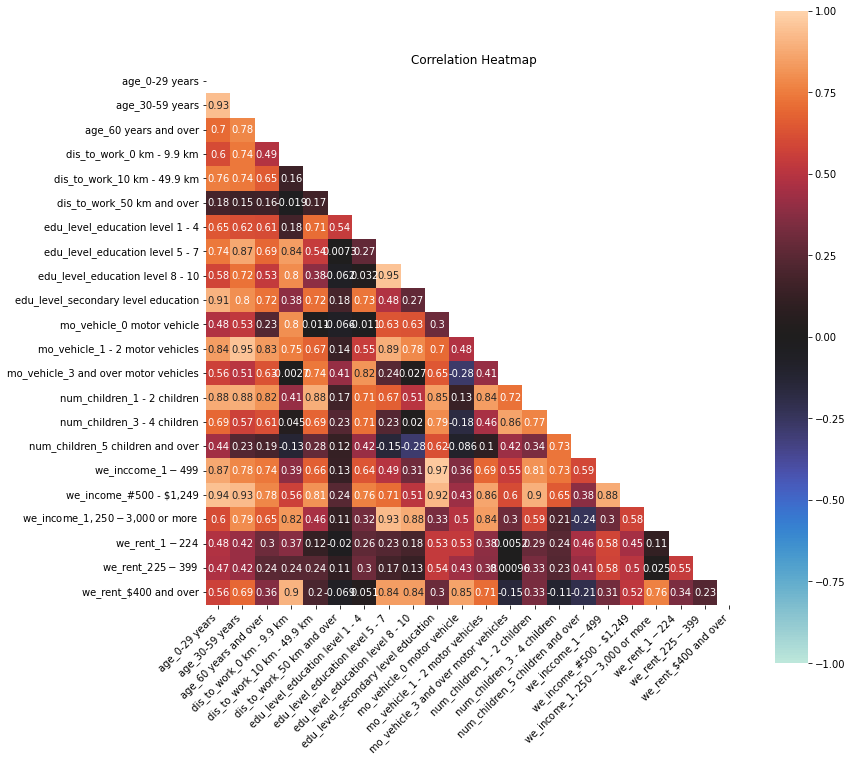

```python
# sort columns name
merged_features_df = merged_features_df.reindex(sorted(merged_features_df.columns), axis=1)

# create corr dataframe
corr_df = merged_features_df.corr()
mask = np.triu(np.ones_like(corr_df, dtype=np.bool))

# plot the correlation dataframe
plt.figure(figsize=(12, 12))
corr_heatmap = sns.heatmap(corr_df,
                           mask=mask,
                           vmin = -1,
                           vmax=1,
                           center=0,
                           square=True,
                           annot=True)
corr_heatmap.set_xticklabels(corr_heatmap.get_xticklabels(),
                             rotation=45,
                             horizontalalignment='right')
corr_heatmap.set_title('Correlation Heatmap')
```

The correlation heatmap shows correlation from dataset combined features.

One of the highest correlation is number of persons with weekly income 1 - 499 dollars and number of persons with secondary education level, the correlation score is 0.97. It is straightforward and not counterintuitive because it is well known fact that the higher a person's education level, the more he earn and vice versa. So if there are a lot of people with low education level in a suburb, that suburb will also contain a lot of people with low level of income

Another correlation that has high score is correlation between number of dwellings with 1 - 2 motor vehicles and number of persons with age 30-59 years.

### Class Proportion

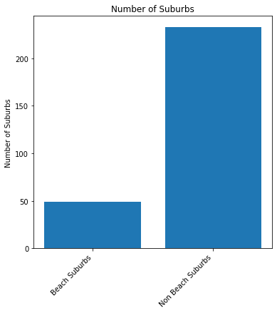

```python
# create datafame and plot
class_proportion_df = pd.DataFrame({"Number of Suburbs" : [len(Is_Beach_df[Is_Beach_df['is_beach'] == 1]),
                                                           len(Is_Beach_df[Is_Beach_df['is_beach'] == 0])]},
                                   index = ['Beach Suburbs', 'Non Beach Suburbs'])
plt.figure(figsize=(6, 6))
plt.title('Number of Suburbs')
plt.ylabel('Number of Suburbs')
plt.xticks(rotation=45, horizontalalignment='right')
plt.bar(class_proportion_df.index, class_proportion_df['Number of Suburbs'])
plt.show()
```

```python
print('Number of beach suburbs:', len(Is_Beach_df[Is_Beach_df['is_beach'] == 1]))
print('Number of non-beach suburbs:',len(Is_Beach_df[Is_Beach_df['is_beach'] == 0]))
```

```
Number of beach suburbs: 49
Number of non-beach suburbs: 233
```

The target class is not balanced. There are 49 beach suburbs and 233 non beach suburbs and the beach suburbs proportion is 17.3 % of total suburbs.

### Map Plotting

```python
# plot sydney suburbs
geo_df = geopandas.read_file('data/Geospatial Data/SA2_2016_AUST.shp')
geo_df = geo_df[geo_df.STE_NAME16=='New South Wales']
geo_df = geo_df[geo_df.GCC_NAME16=='Greater Sydney']
geo_df = geo_df.set_index('SA2_NAME16')
geo_df = pd.merge(geo_df, Is_Beach_df, how='inner', left_index=True, right_index=True)

geo_df['is_beach'] = geo_df['is_beach'].replace({0: 'not beach-suburb', 1: 'beach suburb'})
geo_df['Persons_AGE10P'] = Persons_AGE10P_df.T.idxmax()
geo_df['Persons_WeekyTotalPersonalIncome'] = Persons_WeekyTotalPersonalIncome_df.T.idxmax()
geo_df['Persons_DistancetoWork'] = Persons_DistancetoWork_df.T.idxmax()
geo_df['Dwellings_WeeklyRent'] = Dwellings_WeeklyRent_df.T.idxmax()
geo_df['Dwellings_NumberofMotorVehicles'] = Dwellings_NumberofMotorVehicles_df.T.idxmax()
```

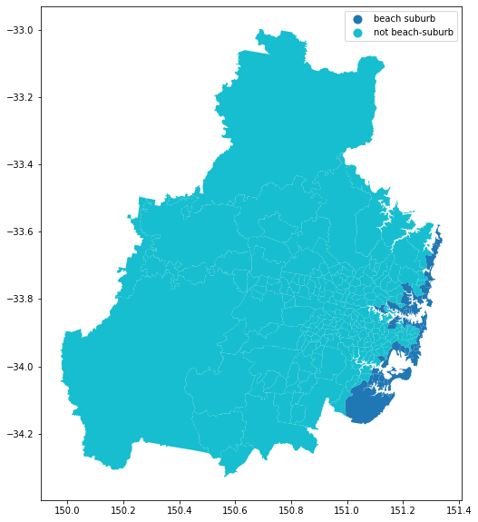

```python
geo_df.plot(column='is_beach', figsize=(10, 10), legend=True)
```

We define beach suburbs as suburbs that face the sea directly. The above map shows our definition of beach suburbs.

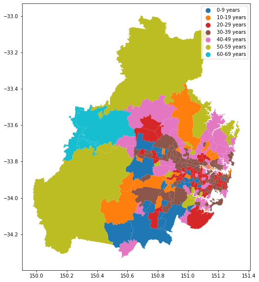

```python
geo_df.plot(column='Persons_AGE10P', figsize=(10, 10), legend=True)
```

The map shows suburbs with highest proportion of certain age groups. For instance, suburbs with blue color mean that age group 0-9 years is the biggest proportion of total population in that suburbs. Unfortunately, the map doesn't show easy to recognize pattern related to beach vs non-beach question.

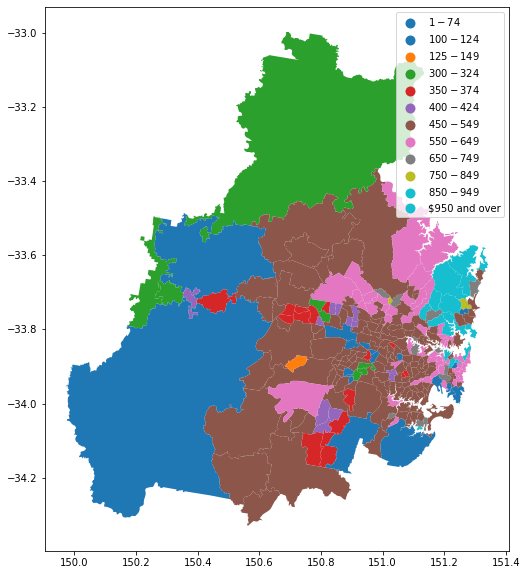

```python
geo_df.plot(column='Dwellings_WeeklyRent', figsize=(10, 10), legend=True)
```

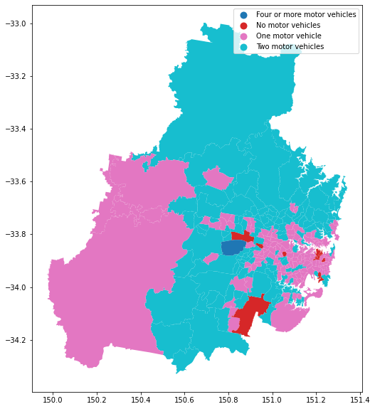

```python
geo_df.plot(column='Dwellings_NumberofMotorVehicles', figsize=(10, 10), legend=True)
```

The map shows suburbs with highest proportion of dwellings with certain number of vehicles. Still, there isn't any easy recognize pattern that is related to beach vs non-beach question.

## Support Vector Machine

### All Features

```python
# use 10-fold cross validation to validate SVM model
clf = svm.SVC(random_state=42)
scores_svm_default = cross_val_score(clf, combined_df, Is_Beach_df['is_beach'], cv=10, verbose=0)
print('Accuracy range, mean & std for SVM using all features:')
print('accuracy range: [%.4f, %.4f]; mean: %.4f; std: %.4f\n'
      % (scores_svm_default.min(), scores_svm_default.max(), scores_svm_default.mean(), scores_svm_default.std()))
```

```
Accuracy range, mean & std for SVM using all features:
accuracy range: [0.8214, 0.9286]; mean: 0.8475; std: 0.0357
```

Using all available features from dataset, the 10-fold cross validation mean accuracy score of Support Vector Machine classifer is 0.8475.

### Merged Features

```python
# use 10-fold cross validation to validate the model
clf = svm.SVC(random_state=42)
scores_svm_default = cross_val_score(clf, merged_features_df, Is_Beach_df['is_beach'], cv=10, verbose=0)
print('Accuracy range, mean & std for SVM using dataframe with several related features combined:')
print('accuracy range: [%.4f, %.4f]; mean: %.4f; std: %.4f\n'
      % (scores_svm_default.min(), scores_svm_default.max(), scores_svm_default.mean(), scores_svm_default.std()))
```

```
Accuracy range, mean & std for SVM using dataframe with several related features combined:
accuracy range: [0.7931, 0.8929]; mean: 0.8371; std: 0.0314
```

Merged features dataframe is dataframe with combined features from combined dataframe. Number of features is reduced from 72 to 22. The cross validation score is 0.8371, worse than using 72 features.

### Features That Are Highly Correlated With Target

```python
# filter features that have correlation value over certain threshold, in this case 0.2
features_class_df = combined_df.join(Is_Beach_df)
features_class_corr_df = features_class_df.corr()
features_class_corr_df['is_beach'][features_class_corr_df['is_beach'] > 0.2]
```

```
$2,000-$2,999 ($104,000-$155,999)                 0.29
$3,000 or more ($156,000 or more)                 0.47
Over 0 km to less than 2.5 km                     0.24
2.5 km to less than 10 km                         0.24
250 km and over                                   0.30
Graduate Diploma and Graduate Certificate Level   0.25
Bachelor Degree Level                             0.21
$950 and over                                     0.44
$850-$949                                         0.41
$750-$849                                         0.36
$650-$749                                         0.26
$550-$649                                         0.22
is_beach                                          1.00
Name: is_beach, dtype: float64
```

```python
# create dataframe using filtered features
h_corr_features = features_class_corr_df['is_beach'][features_class_corr_df['is_beach'] > 0.2]
h_corr_features = h_corr_features[:-1]
h_corr_df = combined_df[h_corr_features.index]

# use 10-fold cross valication to validate the model
clf = svm.SVC(random_state=42)
scores_svm_default = cross_val_score(clf, h_corr_df, Is_Beach_df['is_beach'], cv=10, verbose=0)
print('Accuracy range, mean & std for SVM using dataframe with features that are highly correlated with target:')
print('accuracy range: [%.4f, %.4f]; mean: %.4f; std: %.4f\n'
      % (scores_svm_default.min(), scores_svm_default.max(), scores_svm_default.mean(), scores_svm_default.std()))
```

```
Accuracy range, mean & std for SVM using dataframe with features that are highly correlated with target:
accuracy range: [0.7241, 0.9286]; mean: 0.8337; std: 0.0508
```

```python
# iterate over several values of threshold
for corr_threshold in [0.1, 0.15, 0.2, 0.25, 0.3, 0.35, 0.4]:
    h_corr_features = features_class_corr_df['is_beach'][features_class_corr_df['is_beach'] > corr_threshold]
    h_corr_features = h_corr_features[:-1]
    h_corr_df = combined_df[h_corr_features.index]
    clf = svm.SVC(random_state=42)
    scores_svm_default = cross_val_score(clf, h_corr_df, Is_Beach_df['is_beach'], cv=10, verbose=0)
    print('Using dataframe with features that has correlation value greater than %.2f with target (%.d features):' %(corr_threshold, len(h_corr_df.columns)))
    print('accuracy range: [%.4f, %.4f]; mean: %.4f; std: %.4f\n'
          % (scores_svm_default.min(), scores_svm_default.max(), scores_svm_default.mean(), scores_svm_default.std()))
```

```
Using dataframe with features that has correlation value greater than 0.10 with target (22 features):
accuracy range: [0.8214, 0.9286]; mean: 0.8441; std: 0.0358

Using dataframe with features that has correlation value greater than 0.15 with target (17 features):
accuracy range: [0.6552, 0.9286]; mean: 0.8268; std: 0.0673

Using dataframe with features that has correlation value greater than 0.20 with target (12 features):
accuracy range: [0.7241, 0.9286]; mean: 0.8337; std: 0.0508

Using dataframe with features that has correlation value greater than 0.25 with target (8 features):
accuracy range: [0.7143, 0.9286]; mean: 0.8401; std: 0.0541

Using dataframe with features that has correlation value greater than 0.30 with target (5 features):
accuracy range: [0.7143, 0.9286]; mean: 0.8437; std: 0.0563

Using dataframe with features that has correlation value greater than 0.35 with target (4 features):
accuracy range: [0.7143, 0.9286]; mean: 0.8437; std: 0.0563

Using dataframe with features that has correlation value greater than 0.40 with target (3 features):
accuracy range: [0.7143, 0.9286]; mean: 0.8437; std: 0.0563
```

Iterating over several threshold values, highest cross validation mean score is achieved when the correlation value threshold is over 0.10 (22 features) and the cross validation mean score is 0.8441.

### Features Selected Using SelectKBest

```python
# use SelectKBest to select features, in this case select 10 best features
kbestfeatures = SelectKBest(chi2, k=10)
kbestfeatures_loaded = kbestfeatures.fit_transform(combined_df, Is_Beach_df['is_beach'])
mask = kbestfeatures.get_support()
combined_df.columns[mask]
```

```
Index(['$2,000-$2,999 ($104,000-$155,999)',
       '$3,000 or more ($156,000 or more)', 'Over 0 km to less than 2.5 km',
       '2.5 km to less than 10 km', '30 km to less than 50 km',
       'Bachelor Degree Level', 'Secondary Education - Years 9 and below',
       '$950 and over', '$850-$949', '$750-$849'],
      dtype='object')
```

```python
# create dataframe using selected features
kbest_features_df = combined_df[combined_df.columns[mask]]

# cross validate
clf = svm.SVC(random_state=42)
scores_svm_default = cross_val_score(clf, kbest_features_df, Is_Beach_df['is_beach'], cv=10, verbose=0)
print('Accuracy range, mean & std for SVM:')
print('accuracy range: [%.4f, %.4f]; mean: %.4f; std: %.4f\n'
      % (scores_svm_default.min(), scores_svm_default.max(), scores_svm_default.mean(), scores_svm_default.std()))
```

```
Accuracy range, mean & std for SVM:
accuracy range: [0.7241, 0.8929]; mean: 0.8302; std: 0.0450
```

```python
# iterate over several values of k
for k_iter in range(1, 10):
    kbestfeatures = SelectKBest(chi2, k=k_iter)
    kbestfeatures_loaded = kbestfeatures.fit_transform(combined_df, Is_Beach_df['is_beach'])
    mask = kbestfeatures.get_support()
    kbest_features_df = combined_df[combined_df.columns[mask]]
    clf = svm.SVC(random_state=42)
    scores_svm_default = cross_val_score(clf, kbest_features_df, Is_Beach_df['is_beach'], cv=10, verbose=0)
    print('Using dataframe with %d features selected using SelectKBest:' %(k_iter))
    print('accuracy range: [%.4f, %.4f]; mean: %.4f; std: %.4f\n'
          % (scores_svm_default.min(), scores_svm_default.max(), scores_svm_default.mean(), scores_svm_default.std()))
```

```
Using dataframe with 1 features selected using SelectKBest:
accuracy range: [0.7500, 0.8929]; mean: 0.8403; std: 0.0404

Using dataframe with 2 features selected using SelectKBest:
accuracy range: [0.7931, 0.8929]; mean: 0.8369; std: 0.0277

Using dataframe with 3 features selected using SelectKBest:
accuracy range: [0.8214, 0.9286]; mean: 0.8441; std: 0.0358

Using dataframe with 4 features selected using SelectKBest:
accuracy range: [0.8214, 0.8966]; mean: 0.8474; std: 0.0323

Using dataframe with 5 features selected using SelectKBest:
accuracy range: [0.7241, 0.8929]; mean: 0.8302; std: 0.0450

Using dataframe with 6 features selected using SelectKBest:
accuracy range: [0.7586, 0.8929]; mean: 0.8336; std: 0.0374

Using dataframe with 7 features selected using SelectKBest:
accuracy range: [0.6897, 0.8929]; mean: 0.8267; std: 0.0535

Using dataframe with 8 features selected using SelectKBest:
accuracy range: [0.7241, 0.8929]; mean: 0.8302; std: 0.0450

Using dataframe with 9 features selected using SelectKBest:
accuracy range: [0.7241, 0.8929]; mean: 0.8302; std: 0.0450
```

This time, SelectKBest is used to select features and the highest cross validation mean score is achieved when number of features is 4.

### Iterate Overal Several C Values

```python
for c in [0.001, 0.01, 0.1, 1, 10, 100, 1000]:
    clf = svm.SVC(random_state=42, C=c)
    scores_svm_default = cross_val_score(clf, combined_df, Is_Beach_df['is_beach'], cv=10, verbose=0)
    print('Accuracy range, mean & std for SVM using all features, with C =', c, ':')
    print('accuracy range: [%.4f, %.4f]; mean: %.4f; std: %.4f\n'
      % (scores_svm_default.min(), scores_svm_default.max(), scores_svm_default.mean(), scores_svm_default.std()))
```

```
Accuracy range, mean & std for SVM using all features, with C = 0.001 :
accuracy range: [0.8214, 0.8571]; mean: 0.8262; std: 0.0106

Accuracy range, mean & std for SVM using all features, with C = 0.01 :
accuracy range: [0.8214, 0.8571]; mean: 0.8262; std: 0.0106

Accuracy range, mean & std for SVM using all features, with C = 0.1 :
accuracy range: [0.8214, 0.8571]; mean: 0.8262; std: 0.0106

Accuracy range, mean & std for SVM using all features, with C = 1 :
accuracy range: [0.8214, 0.9286]; mean: 0.8475; std: 0.0357

Accuracy range, mean & std for SVM using all features, with C = 10 :
accuracy range: [0.7500, 0.9286]; mean: 0.8441; std: 0.0506

Accuracy range, mean & std for SVM using all features, with C = 100 :
accuracy range: [0.7143, 0.8929]; mean: 0.8262; std: 0.0586

Accuracy range, mean & std for SVM using all features, with C = 1000 :
accuracy range: [0.7500, 0.8966]; mean: 0.8330; std: 0.0513
```

Iterating over several C values, highest cross validation mean score is achieved when the C value is 1 and the cross validation mean score is 0.8475.

For Support Vector Machine, the highest cross validation mean score is achieved when the classifier uses all of the available features and the highest cross valition mean score is 0.8475

## Logistic Regression

### All Features

```python
# Use 10-fold cross validation to validate Logistic Regression model
clf = LogisticRegression(random_state=42, max_iter=8000)
scores_logres_default = cross_val_score(clf, combined_df, Is_Beach_df['is_beach'], cv=10, verbose=0)
print('Accuracy range, mean & std for Logistic Regression using all features:')
print('accuracy range: [%.4f, %.4f]; mean: %.4f; std: %.4f\n'
      % (scores_logres_default.min(), scores_logres_default.max(), scores_logres_default.mean(), scores_logres_default.std()))
```

```
Accuracy range, mean & std for Logistic Regression using all features:
accuracy range: [0.6429, 0.9643]; mean: 0.8021; std: 0.1100
```

### Merged Features

```python
# Use 10-fold cross validation to validate the model
clf = LogisticRegression(random_state=42, max_iter=8000)
scores_logres_default = cross_val_score(clf, merged_features_df, Is_Beach_df['is_beach'], cv=10, verbose=0)
print('Accuracy range, mean & std for Logistic Regression using dataframe with several related features combined:')
print('accuracy range: [%.4f, %.4f]; mean: %.4f; std: %.4f\n'
      % (scores_logres_default.min(), scores_logres_default.max(), scores_logres_default.mean(), scores_logres_default.std()))
```

```
Accuracy range, mean & std for Logistic Regression using dataframe with several related features combined:
accuracy range: [0.6429, 0.9643]; mean: 0.8297; std: 0.0813
```

### Features That Are Highly Correlated With Target

```python
# filter features that have correlation value over certain threshold, in this case 0.2
features_class_df = combined_df.join(Is_Beach_df)
features_class_corr_df = features_class_df.corr()
features_class_corr_df['is_beach'][features_class_corr_df['is_beach'] > 0.2]
```

```
$2,000-$2,999 ($104,000-$155,999)                 0.29
$3,000 or more ($156,000 or more)                 0.47
Over 0 km to less than 2.5 km                     0.24
2.5 km to less than 10 km                         0.24
250 km and over                                   0.30
Graduate Diploma and Graduate Certificate Level   0.25
Bachelor Degree Level                             0.21
$950 and over                                     0.44
$850-$949                                         0.41
$750-$849                                         0.36
$650-$749                                         0.26
$550-$649                                         0.22
is_beach                                          1.00
Name: is_beach, dtype: float64
```

```python
# create dataframe using filtered features
h_corr_features = features_class_corr_df['is_beach'][features_class_corr_df['is_beach'] > 0.2]
h_corr_features = h_corr_features[:-1]
h_corr_df = combined_df[h_corr_features.index]
```

```python
# Use 10-fold cross validation to validate the model
clf = LogisticRegression(random_state=42, max_iter=8000)
scores_logres_default = cross_val_score(clf, h_corr_df, Is_Beach_df['is_beach'], cv=10, verbose=0)
print('Accuracy range, mean & std for Logistic Regression using dataframe with features that are highly correlated with target:')
print('accuracy range: [%.4f, %.4f]; mean: %.4f; std: %.4f\n'
      % (scores_logres_default.min(), scores_logres_default.max(), scores_logres_default.mean(), scores_logres_default.std()))
```

```
Accuracy range, mean & std for Logistic Regression using dataframe with features that are highly correlated with target:
accuracy range: [0.7500, 1.0000]; mean: 0.8474; std: 0.0752
```

```python
# iterate over several values of threshold
for corr_threshold in [0.1, 0.15, 0.2, 0.25, 0.3, 0.35, 0.4]:
    h_corr_features = features_class_corr_df['is_beach'][features_class_corr_df['is_beach'] > corr_threshold]
    h_corr_features = h_corr_features[:-1]
    h_corr_df = combined_df[h_corr_features.index]
    clf = LogisticRegression(random_state=42, max_iter=8000)
    scores_logres_default = cross_val_score(clf, h_corr_df, Is_Beach_df['is_beach'], cv=10, verbose=0)
    print('Using dataframe with features that has correlation value greater than %.2f with target (%.d features):' %(corr_threshold, len(h_corr_df.columns)))
    print('accuracy range: [%.4f, %.4f]; mean: %.4f; std: %.4f\n'
          % (scores_logres_default.min(), scores_logres_default.max(), scores_logres_default.mean(), scores_logres_default.std()))
```

```
Using dataframe with features that has correlation value greater than 0.10 with target (22 features):
accuracy range: [0.7500, 0.9643]; mean: 0.8440; std: 0.0642

Using dataframe with features that has correlation value greater than 0.15 with target (17 features):
accuracy range: [0.7143, 1.0000]; mean: 0.8654; std: 0.0742

Using dataframe with features that has correlation value greater than 0.20 with target (12 features):
accuracy range: [0.7500, 1.0000]; mean: 0.8474; std: 0.0752

Using dataframe with features that has correlation value greater than 0.25 with target (8 features):
accuracy range: [0.6786, 0.9286]; mean: 0.8331; std: 0.0719

Using dataframe with features that has correlation value greater than 0.30 with target (5 features):
accuracy range: [0.7241, 0.9643]; mean: 0.8266; std: 0.0631

Using dataframe with features that has correlation value greater than 0.35 with target (4 features):
accuracy range: [0.7241, 0.9643]; mean: 0.8266; std: 0.0631

Using dataframe with features that has correlation value greater than 0.40 with target (3 features):
accuracy range: [0.7143, 0.9643]; mean: 0.8335; std: 0.0651
```

Iterating over several threshold values, highest cross validation mean score is achieved when the correlation value threshold is over 0.15 (17 features) and the cross validation mean score is 0.8654.

### Features Selected Using SelectKBest

```python
# use SelectKBest to select features, in this case select 10 best features
kbestfeatures = SelectKBest(chi2, k=10)
kbestfeatures_loaded = kbestfeatures.fit_transform(combined_df, Is_Beach_df['is_beach'])
mask = kbestfeatures.get_support()
combined_df.columns[mask]
```

```
Index(['$2,000-$2,999 ($104,000-$155,999)',
       '$3,000 or more ($156,000 or more)', 'Over 0 km to less than 2.5 km',
       '2.5 km to less than 10 km', '30 km to less than 50 km',
       'Bachelor Degree Level', 'Secondary Education - Years 9 and below',
       '$950 and over', '$850-$949', '$750-$849'],
      dtype='object')
```

```python
# create dataframe using selected features
kbest_features_df = combined_df[combined_df.columns[mask]]

# cross validate
clf = LogisticRegression(random_state=42, max_iter=8000)
scores_logres_default = cross_val_score(clf, kbest_features_df, Is_Beach_df['is_beach'], cv=10, verbose=0)
print('Accuracy range, mean & std for Logistic Regression:')
print('accuracy range: [%.4f, %.4f]; mean: %.4f; std: %.4f\n'
      % (scores_logres_default.min(), scores_logres_default.max(), scores_logres_default.mean(), scores_logres_default.std()))
```

```
Accuracy range, mean & std for Logistic Regression:
accuracy range: [0.7143, 1.0000]; mean: 0.8228; std: 0.0825
```

```python
# iterate over several values of k
for k_iter in range(1, 10):
    kbestfeatures = SelectKBest(chi2, k=k_iter)
    kbestfeatures_loaded = kbestfeatures.fit_transform(combined_df, Is_Beach_df['is_beach'])
    mask = kbestfeatures.get_support()
    kbest_features_df = combined_df[combined_df.columns[mask]]
    clf = LogisticRegression(random_state=42, max_iter=8000)
    scores_logres_default = cross_val_score(clf, kbest_features_df, Is_Beach_df['is_beach'], cv=10, verbose=0)
    print('Using dataframe with %d features selected using SelectKBest:' %(k_iter))
    print('accuracy range: [%.4f, %.4f]; mean: %.4f; std: %.4f\n'
          % (scores_logres_default.min(), scores_logres_default.max(), scores_logres_default.mean(), scores_logres_default.std()))
```

```
Using dataframe with 1 features selected using SelectKBest:
accuracy range: [0.7143, 0.9310]; mean: 0.8472; std: 0.0603

Using dataframe with 2 features selected using SelectKBest:
accuracy range: [0.7143, 0.9286]; mean: 0.8473; std: 0.0581

Using dataframe with 3 features selected using SelectKBest:
accuracy range: [0.6786, 0.8929]; mean: 0.8331; std: 0.0582

Using dataframe with 4 features selected using SelectKBest:
accuracy range: [0.7500, 0.9643]; mean: 0.8436; std: 0.0647

Using dataframe with 5 features selected using SelectKBest:
accuracy range: [0.7143, 1.0000]; mean: 0.8227; std: 0.0731

Using dataframe with 6 features selected using SelectKBest:
accuracy range: [0.7143, 1.0000]; mean: 0.8227; std: 0.0731

Using dataframe with 7 features selected using SelectKBest:
accuracy range: [0.7143, 1.0000]; mean: 0.8228; std: 0.0777

Using dataframe with 8 features selected using SelectKBest:
accuracy range: [0.7143, 1.0000]; mean: 0.8262; std: 0.0755

Using dataframe with 9 features selected using SelectKBest:
accuracy range: [0.7143, 1.0000]; mean: 0.8228; std: 0.0777
```

### Iterate Overal Several C Values

```python
h_corr_features = features_class_corr_df['is_beach'][features_class_corr_df['is_beach'] > 0.15]
h_corr_features = h_corr_features[:-1]
h_corr_df = combined_df[h_corr_features.index]
for c in [0.001, 0.01, 0.1, 1, 10, 100, 1000]:
    clf = LogisticRegression(random_state=42, max_iter=8000, C=c)
    scores_logres_default = cross_val_score(clf, h_corr_df, Is_Beach_df['is_beach'], cv=10, verbose=0)
    print('Accuracy range, mean & std for Logistic Regression using features with correlation value over 0.1 with target, with C =', c, ':')
        #print('Accuracy range, mean & std for SVM using all features, with C =', c, ':')
    print('accuracy range: [%.4f, %.4f]; mean: %.4f; std: %.4f\n'
      % (scores_logres_default.min(), scores_logres_default.max(), scores_logres_default.mean(), scores_logres_default.std()))
```

```
Accuracy range, mean & std for Logistic Regression using features with correlation value over 0.1 with target, with C = 0.001 :
accuracy range: [0.7857, 1.0000]; mean: 0.8654; std: 0.0631

Accuracy range, mean & std for Logistic Regression using features with correlation value over 0.1 with target, with C = 0.01 :
accuracy range: [0.7143, 1.0000]; mean: 0.8654; std: 0.0742

Accuracy range, mean & std for Logistic Regression using features with correlation value over 0.1 with target, with C = 0.1 :
accuracy range: [0.7143, 1.0000]; mean: 0.8654; std: 0.0742

Accuracy range, mean & std for Logistic Regression using features with correlation value over 0.1 with target, with C = 1 :
accuracy range: [0.7143, 1.0000]; mean: 0.8654; std: 0.0742

Accuracy range, mean & std for Logistic Regression using features with correlation value over 0.1 with target, with C = 10 :
accuracy range: [0.7143, 1.0000]; mean: 0.8654; std: 0.0742

Accuracy range, mean & std for Logistic Regression using features with correlation value over 0.1 with target, with C = 100 :
accuracy range: [0.7143, 1.0000]; mean: 0.8654; std: 0.0742

Accuracy range, mean & std for Logistic Regression using features with correlation value over 0.1 with target, with C = 1000 :
accuracy range: [0.7143, 1.0000]; mean: 0.8654; std: 0.0742
```

Iterating over several C values doesn't affect the cross validation mean score.

The highest cross validation score for Logistic Regression is 0.8654 and condition to achieve that is to use dataframe with features which correlation score is over 0.15.

## Random Forest

### All Features

```python
# Use 10-fold cross validation to validate Logistic Regression model
clf = RandomForestClassifier(max_depth=2, random_state=42)
scores_rfc_default = cross_val_score(clf, combined_df, Is_Beach_df['is_beach'], cv=10, verbose=0)
print('Accuracy range, mean & std for Random Forest using all features:')
print('accuracy range: [%.4f, %.4f]; mean: %.4f; std: %.4f\n'
      % (scores_rfc_default.min(), scores_rfc_default.max(), scores_rfc_default.mean(), scores_rfc_default.std()))
```

```
Accuracy range, mean & std for Random Forest using all features:
accuracy range: [0.7857, 0.8621]; mean: 0.8333; std: 0.0232
```

The cross validation mean accuracy score using all features is 0.8333

### Merged Features

```python
# Use 10-fold cross validation to validate the model
clf = RandomForestClassifier(max_depth=2, random_state=42)
scores_rfc_default = cross_val_score(clf, merged_features_df, Is_Beach_df['is_beach'], cv=10, verbose=0)
print('Accuracy range, mean & std for Random Forest using dataframe with several related features combined:')
print('accuracy range: [%.4f, %.4f]; mean: %.4f; std: %.4f\n'
      % (scores_rfc_default.min(), scores_rfc_default.max(), scores_rfc_default.mean(), scores_rfc_default.std()))
```

```
Accuracy range, mean & std for Random Forest using dataframe with several related features combined:
accuracy range: [0.8214, 0.8966]; mean: 0.8403; std: 0.0292
```

When the features are combined, the cross validation mean accuracy score is 0.8403.

### Features That Are Highly Correlated With Target

```python
# filter features that have correlation value over certain threshold, in this case 0.2
features_class_df = combined_df.join(Is_Beach_df)
features_class_corr_df = features_class_df.corr()
features_class_corr_df['is_beach'][features_class_corr_df['is_beach'] > 0.2]
```

```
$2,000-$2,999 ($104,000-$155,999)                 0.29
$3,000 or more ($156,000 or more)                 0.47
Over 0 km to less than 2.5 km                     0.24
2.5 km to less than 10 km                         0.24
250 km and over                                   0.30
Graduate Diploma and Graduate Certificate Level   0.25
Bachelor Degree Level                             0.21
$950 and over                                     0.44
$850-$949                                         0.41
$750-$849                                         0.36
$650-$749                                         0.26
$550-$649                                         0.22
is_beach                                          1.00
Name: is_beach, dtype: float64
```

```python
# create dataframe using filtered features
h_corr_features = features_class_corr_df['is_beach'][features_class_corr_df['is_beach'] > 0.2]
h_corr_features = h_corr_features[:-1]
h_corr_df = combined_df[h_corr_features.index]

# Use 10-fold cross validation to validate the model
clf = RandomForestClassifier(max_depth=2, random_state=42)
scores_rfc_default = cross_val_score(clf, h_corr_df, Is_Beach_df['is_beach'], cv=10, verbose=0)
print('Accuracy range, mean & std for Random Forest using dataframe with features that are highly correlated with target:')
print('accuracy range: [%.4f, %.4f]; mean: %.4f; std: %.4f\n'
      % (scores_rfc_default.min(), scores_rfc_default.max(), scores_rfc_default.mean(), scores_rfc_default.std()))
```

```
Accuracy range, mean & std for Random Forest using dataframe with features that are highly correlated with target:
accuracy range: [0.6897, 0.8621]; mean: 0.8087; std: 0.0561
```

```python
# iterate over several values of threshold
for corr_threshold in [0.1, 0.15, 0.2, 0.25, 0.3, 0.35, 0.4]:
    h_corr_features = features_class_corr_df['is_beach'][features_class_corr_df['is_beach'] > corr_threshold]
    h_corr_features = h_corr_features[:-1]
    h_corr_df = combined_df[h_corr_features.index]
    clf = RandomForestClassifier(max_depth=2, random_state=42)
    scores_rfc_default = cross_val_score(clf, h_corr_df, Is_Beach_df['is_beach'], cv=10, verbose=0)
    print('Using dataframe with features that has correlation value greater than %.2f with target (%.d features):' %(corr_threshold, len(h_corr_df.columns)))
    print('accuracy range: [%.4f, %.4f]; mean: %.4f; std: %.4f\n'
          % (scores_rfc_default.min(), scores_rfc_default.max(), scores_rfc_default.mean(), scores_rfc_default.std()))
```

```
Using dataframe with features that has correlation value greater than 0.10 with target (22 features):
accuracy range: [0.7241, 0.8621]; mean: 0.8300; std: 0.0393

Using dataframe with features that has correlation value greater than 0.15 with target (17 features):
accuracy range: [0.7143, 0.8929]; mean: 0.8228; std: 0.0497

Using dataframe with features that has correlation value greater than 0.20 with target (12 features):
accuracy range: [0.6897, 0.8621]; mean: 0.8087; std: 0.0561

Using dataframe with features that has correlation value greater than 0.25 with target (8 features):
accuracy range: [0.7143, 0.8929]; mean: 0.8192; std: 0.0484

Using dataframe with features that has correlation value greater than 0.30 with target (5 features):
accuracy range: [0.6897, 0.9286]; mean: 0.8159; std: 0.0655

Using dataframe with features that has correlation value greater than 0.35 with target (4 features):
accuracy range: [0.6897, 0.9286]; mean: 0.8230; std: 0.0695

Using dataframe with features that has correlation value greater than 0.40 with target (3 features):
accuracy range: [0.6897, 0.9286]; mean: 0.8230; std: 0.0695
```

Iterating over several level of correlatio threshold, the highest cross validation mean accuracy score is 0.83. It is achieved when classfier uses 22 features.

### Features Selected Using SelectKBest

```python
# use SelectKBest to select features, in this case select 10 best features
kbestfeatures = SelectKBest(chi2, k=10)
kbestfeatures_loaded = kbestfeatures.fit_transform(combined_df, Is_Beach_df['is_beach'])
mask = kbestfeatures.get_support()
combined_df.columns[mask]
```

```
Index(['$2,000-$2,999 ($104,000-$155,999)',
       '$3,000 or more ($156,000 or more)', 'Over 0 km to less than 2.5 km',
       '2.5 km to less than 10 km', '30 km to less than 50 km',
       'Bachelor Degree Level', 'Secondary Education - Years 9 and below',
       '$950 and over', '$850-$949', '$750-$849'],
      dtype='object')
```

```python
# create dataframe using selected features
kbest_features_df = combined_df[combined_df.columns[mask]]

# cross validate
clf = RandomForestClassifier(max_depth=2, random_state=42)
scores_rfc_default = cross_val_score(clf, kbest_features_df, Is_Beach_df['is_beach'], cv=10, verbose=0)
print('Accuracy range, mean & std for SVM:')
print('accuracy range: [%.4f, %.4f]; mean: %.4f; std: %.4f\n'
      % (scores_rfc_default.min(), scores_rfc_default.max(), scores_rfc_default.mean(), scores_rfc_default.std()))
```

```
Accuracy range, mean & std for SVM:
accuracy range: [0.6897, 0.9286]; mean: 0.8230; std: 0.0617
```

```python
# iterate over several values of k
for k_iter in range(1, 10):
    kbestfeatures = SelectKBest(chi2, k=k_iter)
    kbestfeatures_loaded = kbestfeatures.fit_transform(combined_df, Is_Beach_df['is_beach'])
    mask = kbestfeatures.get_support()
    kbest_features_df = combined_df[combined_df.columns[mask]]
    clf = RandomForestClassifier(max_depth=2, random_state=42)
    scores_rfc_default = cross_val_score(clf, kbest_features_df, Is_Beach_df['is_beach'], cv=10, verbose=0)
    print('Using dataframe with %d features selected using SelectKBest:' %(k_iter))
    print('accuracy range: [%.4f, %.4f]; mean: %.4f; std: %.4f\n'
          % (scores_rfc_default.min(), scores_rfc_default.max(), scores_rfc_default.mean(), scores_rfc_default.std()))
```

```
Using dataframe with 1 features selected using SelectKBest:
accuracy range: [0.7143, 0.8929]; mean: 0.8331; std: 0.0512

Using dataframe with 2 features selected using SelectKBest:
accuracy range: [0.7500, 0.9286]; mean: 0.8298; std: 0.0443

Using dataframe with 3 features selected using SelectKBest:
accuracy range: [0.7143, 0.9286]; mean: 0.8334; std: 0.0551

Using dataframe with 4 features selected using SelectKBest:
accuracy range: [0.7143, 0.9286]; mean: 0.8331; std: 0.0512

Using dataframe with 5 features selected using SelectKBest:
accuracy range: [0.6897, 0.9286]; mean: 0.8230; std: 0.0617

Using dataframe with 6 features selected using SelectKBest:
accuracy range: [0.7143, 0.9286]; mean: 0.8264; std: 0.0511

Using dataframe with 7 features selected using SelectKBest:
accuracy range: [0.7931, 0.9286]; mean: 0.8405; std: 0.0358

Using dataframe with 8 features selected using SelectKBest:
accuracy range: [0.7500, 0.9643]; mean: 0.8334; std: 0.0527

Using dataframe with 9 features selected using SelectKBest:
accuracy range: [0.7500, 0.9286]; mean: 0.8299; std: 0.0439
```

Using features selected by SelectKBest, The highest cross validation mean score is 0.8405, when the number of features is 7.

For Random Forest classifier, the highest cross validation mean accuracy score is 0.8405 and it is achieved when the dataframe which is used for learning has 7 features selected by SelectKBest.

## Conclusion

For Support Vector Machine, the highest cross validation mean score is achieved when the classifier uses all of the available features and the highest cross validation mean score is 0.8475. The highest cross validation score for Logistic Regression is 0.8654 and condition to achieve that is to use dataframe with features which correlation score is over 0.15. For Random Forest classifier, the highest cross validation mean accuracy score is 0.8405 and it is achieved when the dataframe which is used for learning has 7 features selected by SelectKBest.